# Twitter Following among US Senators

A Social Network Analysis using ERGMs

By Jessica Eberhart

### Introduction

Social media plays an important role in modern politics. Analyzing politician’s use of social media cannot only provide insights on how politicians connect their voters, but also how they connect to each other. Against this background, I aim to answer the following research question: *How and why do US senators follow other senators on Twitter?*

### Theory and Hypotheses

There are many possible theoretical explanations for the formation of ties. This report will focus on two of the three broad categories identified by [Lusher et al. (2000, p. 24)](https://www.cambridge.org/core/books/exponential-random-graph-models-for-social-networks/9296EE2B53CDEF9FE9E2E981E2FDB8A8): *self-organizing network processes* in which network patterns form due to internal processes of the system of network ties and *attribute-based processes* in which attributes of actors come into play in the formation of network ties. Deriving two hypotheses reflecting these two processes, the aim of this report is to test whether endogenous (H1), exogenous (H2) or a complex combination of both can explain the overall Twitter following network structure.  
**H1: Social media ties are formed as a result of senators’ decisions:**  
Senator X follows senator Y because i) senator Y follows senator X (*reciprocity*), or because ii) a lot of other senators follow senator Y (*popularity*).  
**H2: Social media ties are formed as a result of senators’ attributes:**  
Senator X follows senator Y because senator Y is similar to senator X (*homophily*).

### Network Visualization

To test the hypotheses, a social network analysis of US senators’ Twitter following connections from 2016 is conducted. The one-mode network consists of 20 senators with 183 directed ties that represent a senator following another senator’s Twitter account. The 20 senators were chosen by randomly selecting 5 senators from the four US regions: the Northeast, the Midwest, the South and the West as defined by the [US Census Bureau](https://www2.census.gov/geo/pdfs/maps-data/maps/reference/us_regdiv.pdf).

[figure not shown]

Fig. 1: Twitter Connections among US Senators (2016)

### Modelling

Three ERGMs are employed separately to test which processes contribute to the formation of the above network structure: the first model captures the structural effects by including *dyad-dependent* terms for popularity and reciprocity (gwidegree, gwodegree, mutual). The second model includes *dyad-independent* terms regressing the formation of ties on senator attribute similarities for party membership, gender, age and years in office (nodematch and absdiff), and the third model includes both the structural effects and actor attribute effects.

### Results

Statistical models

|  | Model 1 | Model 2 | Model 3 |
| --- | --- | --- | --- |
| mutual | 1.07** |  | 0.54 |
|  | (0.40) |  | (0.42) |
| gwideg.fixed.4.5 | 26.45 |  | 19.52*** |
|  | (17.57) |  | (1.38) |
| gwodeg.fixed.4.5 | -27.63*** |  | -35.05*** |
|  | (1.68) |  | (2.81) |
| edges | 0.47 | -0.42 | 13.79*** |
|  | (16.33) | (1.18) | (1.36) |
| nodematch.party |  | 1.31*** | 2.60*** |
|  |  | (0.25) | (0.42) |
| nodefactor.party.I |  | 0.73* | 1.04*** |
|  |  | (0.35) | (0.22) |
| nodefactor.party.R |  | -0.26 | -0.27* |
|  |  | (0.20) | (0.11) |
| nodematch.gender |  | 0.47 | 0.66 |
|  |  | (0.40) | (0.49) |
| nodefactor.gender.M |  | -0.52 | -0.47 |
|  |  | (0.36) | (0.37) |
| absdiff.age |  | -0.02 | -0.02 |
|  |  | (0.01) | (0.01) |
| nodecov.age |  | -0.00 | -0.00 |
|  |  | (0.01) | (0.01) |
| absdiff.office |  | -0.04 | -0.02 |
|  |  | (0.03) | (0.02) |
| nodecov.office |  | 0.07** | 0.02 |
|  |  | (0.02) | (0.01) |
| AIC | 357.68 | 490.85 | 313.94 |
| BIC | 373.44 | 530.25 | 365.16 |
| Log Likelihood | -174.84 | -235.43 | -143.97 |

***p < 0.001; **p < 0.01; *p < 0.05

In the **endogenous model 1**, reciprocity is a significant factor influencing the formation of Twitter followings. Furthermore, the parameter associated with the popularity statistic (gwodegree) is negative and highly significant which points to preferential attachment with respect to outgoing ties (outgoing Twitter following).  
In the **exogenous model 2**, the homophily effect of following senators from the same party is highly significant. In addition, it seems that senators being in office longer than others have a tendency to have more other senator followers or follow more senators.  
In the **complete model 3**, the homophily effect from the same party membership remains, however, the reciprocity effect disappears and the preferential attachment effects becomes even more important (with the gwidegree becoming signficiant as well). In other words, once we take into account that actors seem to be more likely to form ties with senators from the same party, it becomes clear that senators do not so much follow other senators because they follow them back. Instead, the results indicate that senators follow other senators because they are in the same party as them or because they are popular on Twitter (have many outgoing and incoming ties; i.e. Twitter followings).

### Model Fit

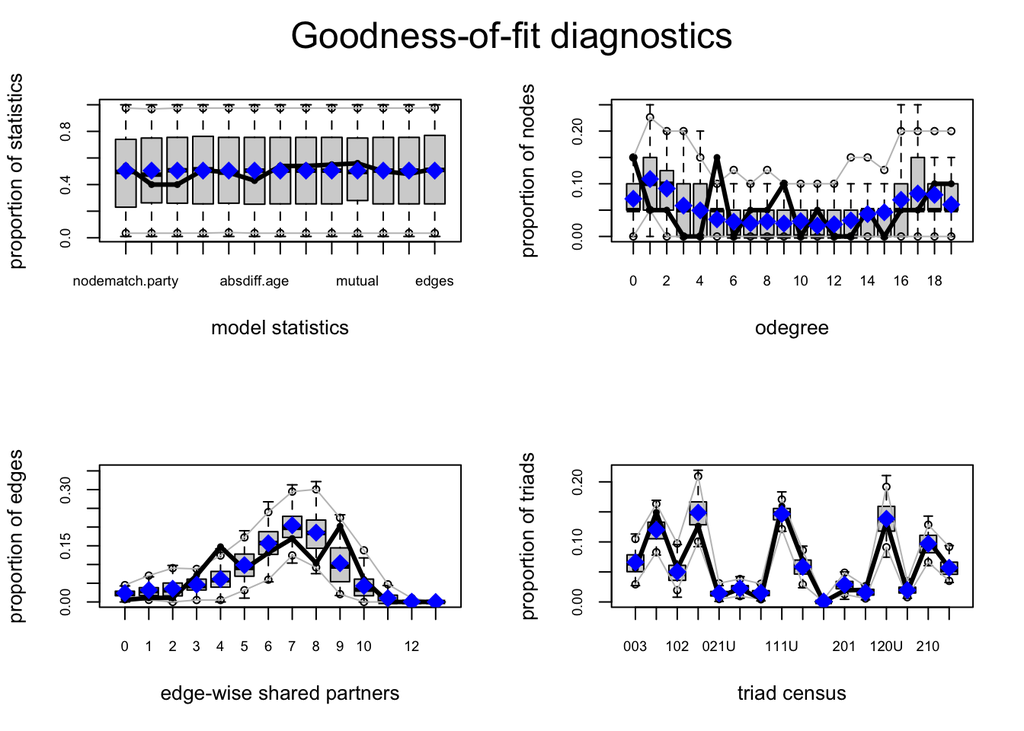

Fig. 2: Hunter’s diagnostics plots

The plots of the GOF show that the ERGM parameters fail to reproduce the network statistics seen in the original data on networks simulated from the fitted model since out-degreee and the edge-wise shared partners have both over- and undervalued estimations of the data. In contrast, the observed structure statistics of triad census can represent the simulated structure statistics surprisingly well which implies a good fit of the ERGM in this regard. Nonetheless, the GOF overall results cast significant doubt on the model’s validity which means that the discussed results must be interpreted in caution.

### Conclusion

How and why do US senators follow other senators on Twitter? In conclusion, the social network analysis showed that the formation of ties on Twitter seem to be the result of a complex mixture of both structural and individual attribute-level processes. As such, the ERGM proved to be a strong method to detect underlying patterns in social networks because it was able to account simultaneously for both the structural as well as actor effects. Yet, caution is required for the validity of the obtained results as the goodness-for-fit tests show signs of weaknesses. Future studies are advised to incorporate more nodes as well as additional attribute parameters to obtain a better suited model and more accurately explain Twitter following ties among senators.